# Lab 5: Hierarchical models and likelihood profiles

Kyle L. Wilson

2023-07-07

```r
knitr::opts_chunk$set(echo = TRUE)
knitr::opts_knit$set(root.dir = rprojroot::find_rstudio_root_file())
library(nlme)
library(stats4)
library(ggplot2)
```

## What are fixed and random effects

*Fixed Effects* are parameters associated with the entire population or with certain repeatable levels of experimental units. - For example, what is the expected body size of a yelloweye rockfish.

*Random Effects* are parameters associated with individual experimental units drawn at random from a population. - For example, what is the expected body size of the 23rd population of yelloweye rockfish, as chosen from a database.

A mixed effects model is a model that has both *fixed effects* and *random effects*. Often the same random effect is assigned to observations sharing a common grouping factor (or other classifying factor). Consider length-at-age data for several (randomly selected) populations of a species. A random factor could be stock and the observations are length-at-age data. Random effects can be thought of as ways of modelling the covariance structure of the data.

Classical (frequentist) and Bayesian methods can be used to estimate the parameters of mixed effects models. This lab and homework will cover Frequentist. Lab 6 will cover their implementation in Stan.

We selected six streams (at random) and measure fish densities at each stream, each surveyed three times. We can then ask the following questions: -What is the density in a typical stream? -What is the variation in density among streams? -What is the variation in density estimates within a stream?

```r
Streams <- readRDS(file="Data/streams.rds")
colnames(Streams) <- c("Stream","true_density","Density")
```

### Fixed effects model

First, let’s fit a relatively simple intercept-only model which speaks to the fish density in a typical stream.

```
## [1] "Linear Fixed Effects Model"
```

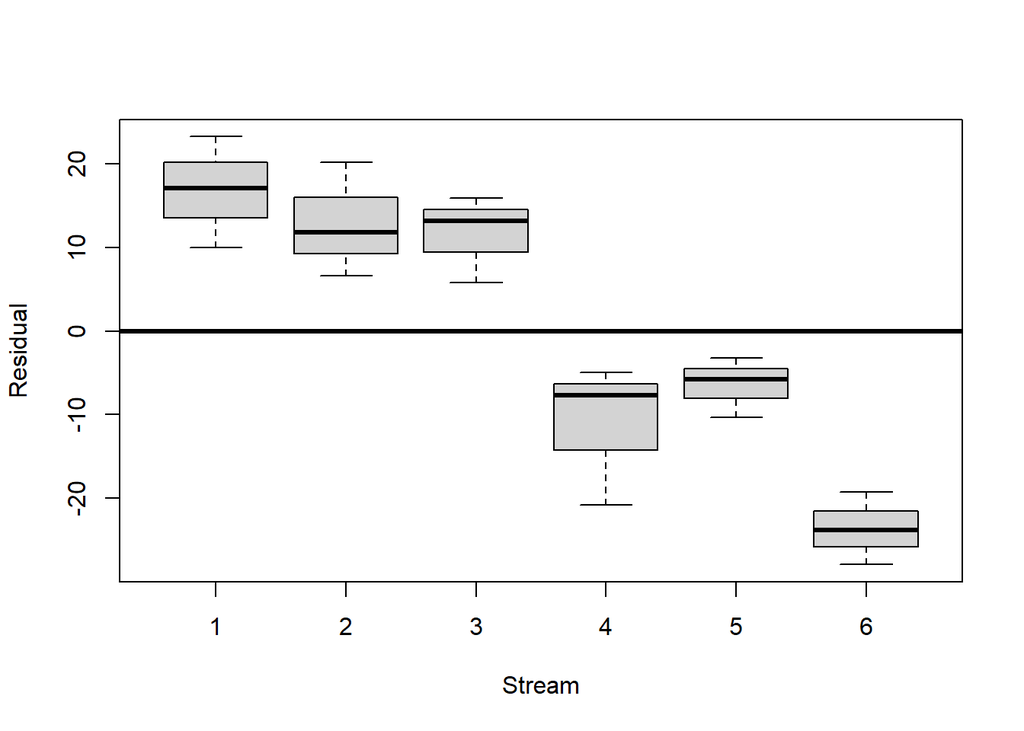

```
##
## Call:
## lm(formula = Density ~ 1, data = Streams)
##
## Residuals:
##    Min     1Q Median     3Q    Max
## -27.95  -9.71   1.29  12.82  23.26
##
## Coefficients:
##             Estimate Std. Error t value Pr(>|t|)
## (Intercept)    78.63       3.78    20.8  1.6e-13 ***
## ---
## Signif. codes:  0 '***' 0.001 '**' 0.01 '*' 0.05 '.' 0.1 ' ' 1
##
## Residual standard error: 16 on 17 degrees of freedom
```

```
## [1] "AIC  153.934277919409"
```

Note that this analysis attributed all the error to within-stream variation. However, our residual plots by stream (as a grouping factor) illustrates that there is between-stream variation in density but we have no way to make any inference or insight on it.

Let’s see if we can ask how do streams vary instead? Fit a linear mixed effects model (and drop the intercept using the `-1` term in `lm()`)

```
## [1] "Linear Fixed Effects Model, with stream-effect"
```

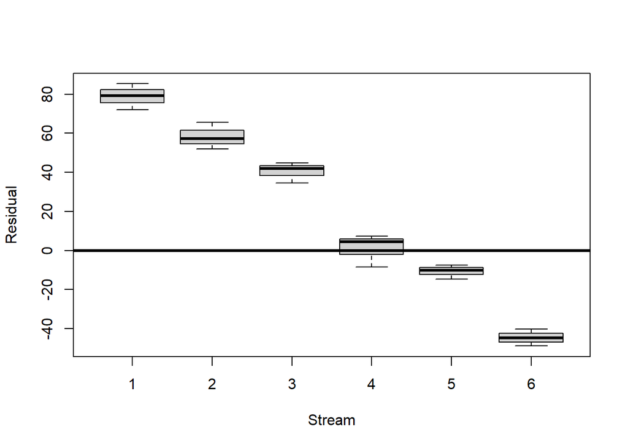

```
##
## Call:
## lm(formula = Density ~ Stream - 1, data = Streams)
##
## Residuals:
##    Min     1Q Median     3Q    Max
## -48.87  -9.68  20.97  55.99  85.29
##
## Coefficients:
##        Estimate Std. Error t value Pr(>|t|)
## Stream    16.59       2.95    5.62  3.1e-05 ***
## ---
## Signif. codes:  0 '***' 0.001 '**' 0.01 '*' 0.05 '.' 0.1 ' ' 1
##
## Residual standard error: 48.8 on 17 degrees of freedom
## Multiple R-squared:  0.65,   Adjusted R-squared:  0.629
## F-statistic: 31.5 on 1 and 17 DF,  p-value: 3.09e-05
```

```
## [1] "AIC  194.023011097565"
```

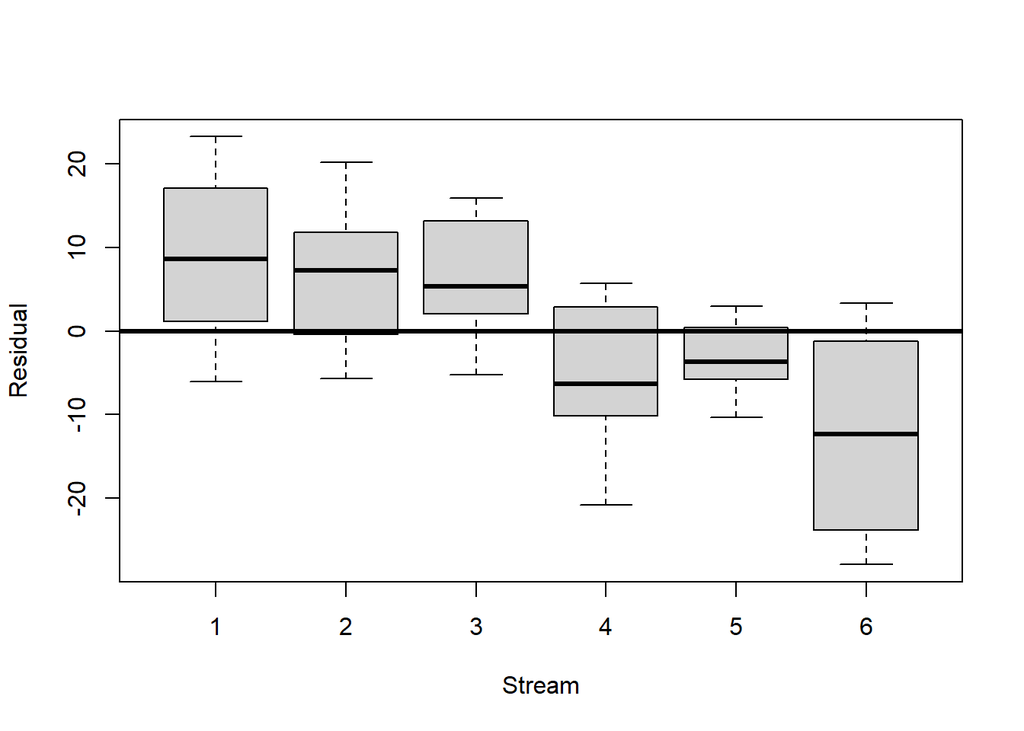

```
## Linear mixed-effects model fit by REML
##   Data: Streams
##     AIC   BIC  logLik
##   133.8 136.3 -63.899
##
## Random effects:
##  Formula: ~1 | Stream
##         (Intercept) Residual
## StdDev:      15.789   6.0839
##
## Fixed effects:  Density ~ 1
##              Value Std.Error DF t-value p-value
## (Intercept) 78.629    6.6033 12  11.908       0
##
## Standardized Within-Group Residuals:
##      Min       Q1      Med       Q3      Max
## -1.67043 -0.82395  0.12567  0.52956  1.29880
##
## Number of Observations: 18
## Number of Groups: 6
```

Now, we’ve taken care of the strong patterning in the residuals and we can now comment on an overall mean and between-stream variance. What are the estimates of the stream-specifics?

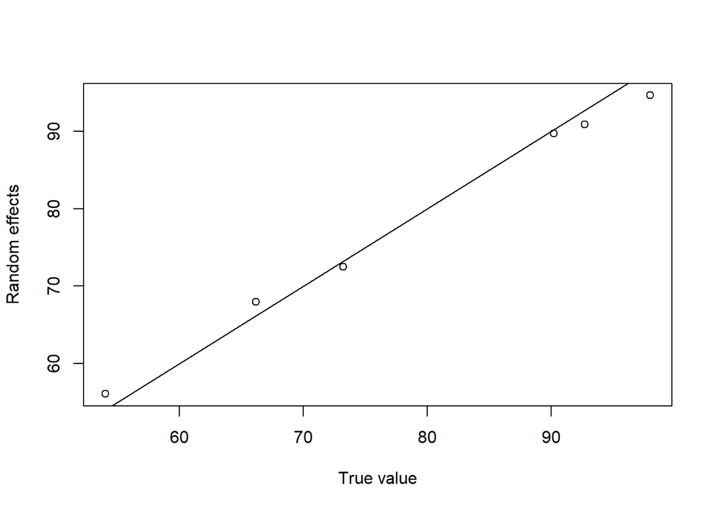

```r
plot(as.numeric(unique(Streams$true_density)),coef(lm3)[[1]],xlab="True value",ylab="Random effects") # extract the stream-level effects (fixed effect + random effects) and compare to true values
abline(b=1,a=0) # add a 1:1 line for comparison
```

### Hierarchical model: what’s under the hood

```r
simpson  <-  function(lowerb, upperb, nbins, stream,beta, sig_e, sig_b)
{
  step <- (upperb-lowerb)/nbins
  b_vec <- seq(lowerb, upperb, by=step)
  frac_vec <- c(1/3, rep(c(4/3, 2/3), times=((nbins+1)-3)/2), 4/3, 1/3)
  sum_comp <- vector(length=length(b_vec))
  for(i in 1:length(b_vec)){
    sum_comp[i] <- frac_vec[i]*norm.lik(bi=b_vec[i], sig_e=sig_e, sig_b=sig_b, beta=beta, stream=stream)
  }
  full_like <- sum(sum_comp)*step
  return(full_like)
}
```

We should be somewhat comfortable with the below function: we pass some parameters to a function and call *Function 2* (which calls *Function 1*) to calculate the joint likelihood.

```r
loglike=function(l_sig_e,l_sig_b,beta)
{
  sig_e <- exp(l_sig_e)
  sig_b<-exp(l_sig_b)
  stream <- c(1,2,3,4,5,6)
  like.str <- vector(length=length(stream))
  for (i in stream)
  {
    like.str[i] <- simpson(lowerb=lowerb, upperb=upperb, nbins=nbins, sig_e=sig_e, sig_b=sig_b, beta=beta, stream=stream[i])
  }
  nll <- (-1)*sum(log(like.str))
  return(nll)
}
```

Now let’s optimize! Rather than `optim()` we will use a similar package called `mle`, which automatically provides some standard errors based on the Hessian matrix from Lab 2. Note that `mle()` is a function, which calls `loglike()`, which calls `simpson()`, which calls `norm.lik()`. It’s why hierarchical models are complicated!

Below, we will the number of bins for our integral and the lower- and upper-bounds to integrate across.

```r
lowerb <- -5 # the lower bound of the integral
upperb <- 5 # the upper bound of the integral
nbins <- 100 # the number of bins (or the step-size) of the integral
fit1=mle(loglike,start=list(l_sig_e=log(10),l_sig_b=log(10),beta=70),nobs=length(Streams$Density),method="BFGS")
summary(fit1)
```

```
## Maximum likelihood estimation
##
## Call:
## mle(minuslogl = loglike, start = list(l_sig_e = log(10), l_sig_b = log(10),
##     beta = 70), method = "BFGS", nobs = length(Streams$Density))
##
## Coefficients:
##         Estimate Std. Error
## l_sig_e   1.8056    0.20412
## l_sig_b   2.6632    0.30624
## beta     78.6267    6.02801
##
## -2 log L: 133.32
```

```r
l_sig_e=coef(fit1)[[1]]
l_sig_b=coef(fit1)[[2]]
sig_e=exp(coef(fit1)[[1]])
sig_b=exp(coef(fit1)[[2]])
beta=coef(fit1)[[3]]
AIC(fit1)
```

```
## [1] 139.32
```

```r
(-1)*logLik(fit1)[1] # the -1 converts to the negative log likelihood
```

```
## [1] 66.658
```

Can you compare this to the estimates from `lme()` or `lme4()`?

```r
summary(fit1)
```

```
## Maximum likelihood estimation
##
## Call:
## mle(minuslogl = loglike, start = list(l_sig_e = log(10), l_sig_b = log(10),
##     beta = 70), method = "BFGS", nobs = length(Streams$Density))
##
## Coefficients:
##         Estimate Std. Error
## l_sig_e   1.8056    0.20412
## l_sig_b   2.6632    0.30624
## beta     78.6267    6.02801
##
## -2 log L: 133.32
```

```r
summary(lm3)
```

```
## Linear mixed-effects model fit by REML
##   Data: Streams
##     AIC   BIC  logLik
##   133.8 136.3 -63.899
##
## Random effects:
##  Formula: ~1 | Stream
##         (Intercept) Residual
## StdDev:      15.789   6.0839
##
## Fixed effects:  Density ~ 1
##              Value Std.Error DF t-value p-value
## (Intercept) 78.629    6.6033 12  11.908       0
##
## Standardized Within-Group Residuals:
##      Min       Q1      Med       Q3      Max
## -1.67043 -0.82395  0.12567  0.52956  1.29880
##
## Number of Observations: 18
## Number of Groups: 6
```

Let’s compute a likelihood profile for the population mean density $\beta$ and compare the 95% confidence intervals from this likelihood profile with that determined using LME.

Likelihood profiling is very similar to the Grid Approximation in Lab 2, but applied to Maximum Likelihood Estimation rather than Bayesian inference. To do this, we set up a sequence of possible parameters (in our case, $\beta$ - the group-level mean density among streams) from which to calculate log-likelihoods from (conditional on the updated ML estimates of the *other* parameters).

We will re-arrange our functions accordingly.

Confidence intervals from likelihood profiling are based on the log-likelihood function. For a given parameter, likelihood theory shows that the upper and lower points along a sequence of potential values in that parameter that fall within 1.92 units of the maximum of the log-likelihood function provide a 95% confidence interval when there is no extrabinomial variation (i.e. c = 1). The value 1.92 comes from being half of the $\chi_2$ value of 3.84 with 1 degree of freedom. Thus, the same confidence interval can also be calculated from the deviance by adding 3.84 to the minimum of the deviance function (where the deviance is the log-likelihood multiplied by -2 minus the -2 log likelihood value of the maxmum likelihood model).

Below is a likelihood profile of the beta parameter (based on a search along $\beta_{MLE}\pm0.75\beta_{MLE}$ constructed for the numerical computation of a mixed-effects model of the Streams dataset. This function calculates the negative log-likelihood profiled across fixed values for beta to assess the 95% confidence intervals, calculated as the minimum and maximum values of β for which $ln\mathcal{L}(\theta|\beta_i )\ge(ln\mathcal{L}(\theta|\beta_{MLE})-1.92)$. The 95% CI from likelihood profiling are compared to the 95% CI calculated from the ‘LME’ package using the function ‘intervals’ in Program R.

```r
b.profile=seq(from=beta-0.75*beta,to=beta+0.75*beta,length=200)
lowerb <- -5
upperb <- 5
nbins <- 100
theta=c(log(sig_e),log(sig_b))
b.pro.fun = function (theta) #(theta)
{
  beta <- b.pro # note that now the estimate of b.pro is fixed
  sig_e <- exp(theta[1]) # in this case, we will fix sig_e as well but we could re-estimate that here
  sig_b <- exp(theta[2]) # in this case, we will fix sig_e as well but we could re-estimate that here
  stream <- c(1,2,3,4,5,6)
  like.str=vector(length=length(stream))
  for (i in stream)
  {
    like.str[i] <- simpson(lowerb=lowerb, upperb=upperb, nbins=nbins,
                        sig_e=sig_e, sig_b=sig_b, beta=beta, stream=stream[i])
  }
  nll <- (-1)*sum(log(like.str))
  return(nll)
}

beta.loglik=rep(NA,length(b.profile))
for(i in 1:length(b.profile))
{
  b.pro <- b.profile[i]
  fit.pro <- optim(theta,b.pro.fun,method="BFGS",control=list(maxit=1000))
  beta.loglik[i] <- fit.pro$value
}
df=data.frame("b.profile"=b.profile,"log-like"=beta.loglik)
plot(b.profile,beta.loglik,type="l",lty=1,lwd=2,col="black",ylab="Negative Log-Likelihood",xlab="Beta")
abline(v=df[,1][which(df[,2]==min(df[,2]))],col="red",lty=1)
x <- which((-1)*beta.loglik>=logLik(fit1)[1]-1.92) # where is the
print(b.profile[c(min(x),max(x))]) # here are the minimum/maximum estimates of beta within the 95% CI
```

```
## [1] 64.699 92.554
```

```r
print(intervals(lm3))
```

```
## Approximate 95% confidence intervals
##
##  Fixed effects:
##              lower   est.  upper
## (Intercept) 64.241 78.629 93.016
##
##  Random Effects:
##   Level: Stream
##                  lower   est.  upper
## sd((Intercept)) 8.2361 15.789 30.267
##
##  Within-group standard error:
##  lower   est.  upper
## 4.0778 6.0839 9.0768
```

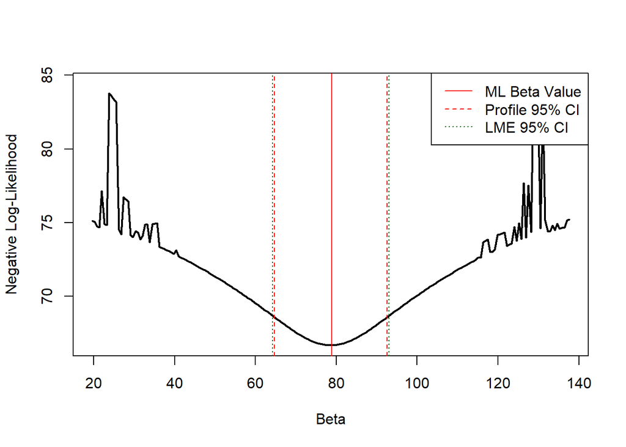

```r
abline(v=df[min(x),1],col="red",lty=2) #printing x and finding the minimum TRUE row number
abline(v=df[max(x),1],col="red",lty=2) #printing x and finding the maximum TRUE row number
abline(v=64.241,col="darkgreen",lty=3) #taken from the LME fits below
abline(v=93.016,col="darkgreen",lty=3) #taken from the LME fits below
legend("topright",c("ML Beta Value","Profile 95% CI","LME 95% CI"),col=c("red","red","darkgreen"),lty=c(1,2,3))
```

Overall, the confidence intervals (CI) between the two methods are very similar with the profile 95% CI of $\beta$ at 64.7-92.6 and the ‘LME’ 95% CI of $\beta$ at 64.2– 93.0. The `lme()` 95% CI are slightly wider than the likelihood profile 95% CI. In part, this is because the ‘LME’ confidence intervals are obtained from the variance-covariance matrix from all parameters (based on the diagonals of the inversed Hessian matrix +/- 1.96) rather than uncertainty in just one parameter, iteratively - but it may also be because the parameter is indeed *not* asymptotically normal.